# SAPFLUXNET / Forrester et al. 2022 — Scaling of Whole-Tree Water Use With Tree Size

# 9 Summary: all scaling exponents

```r
# Helper to pull OLS CI safely
ols_ci_val <- function(fit, term, bound) tryCatch(confint(fit)[term, bound], error = function(e) NA_real_)

summary_df <- tibble(
  Relationship     = c("E ~ D",    "E ~ BA",  "E ~ SA",   "SA ~ D"),
  `x metric`       = c("DBH (cm)", "BA (cm²)","SA (cm²)", "DBH (cm)"),
  `Exp. slope`     = c(2.0,  1.0,  1.0,  1.7),
  # OLS — primary
  `OLS slope`      = c(round(coef(fit_ols_dbh)["log_dbh"],  3),
                        round(coef(fit_ols_ba)["log_ba"],    3),
                        round(coef(fit_ols_sa)["log_sa"],    3),
                        round(coef(fit_ols_sadbh)["log_dbh"],3)),
  `OLS CI lo`      = c(round(ols_ci_val(fit_ols_dbh,  "log_dbh", 1), 3),
                        round(ols_ci_val(fit_ols_ba,   "log_ba",  1), 3),
                        round(ols_ci_val(fit_ols_sa,   "log_sa",  1), 3),
                        round(ols_ci_val(fit_ols_sadbh,"log_dbh", 1), 3)),
  `OLS CI hi`      = c(round(ols_ci_val(fit_ols_dbh,  "log_dbh", 2), 3),
                        round(ols_ci_val(fit_ols_ba,   "log_ba",  2), 3),
                        round(ols_ci_val(fit_ols_sa,   "log_sa",  2), 3),
                        round(ols_ci_val(fit_ols_sadbh,"log_dbh", 2), 3)),
  `OLS R²`         = c(round(summary(fit_ols_dbh)$r.squared,  3),
                        round(summary(fit_ols_ba)$r.squared,   3),
                        round(summary(fit_ols_sa)$r.squared,   3),
                        round(summary(fit_ols_sadbh)$r.squared,3)),
  # SMA — secondary
  `SMA slope`      = c(round(coef(fit_dbh)[2],  3),
                        round(coef(fit_ba)[2],   3),
                        round(coef(fit_sa)[2],   3),
                        round(coef(fit_sadbh)[2],3)),
  `SMA CI lo`      = c(round(fit_dbh$coef[[1]][2,2],   3),
                        round(fit_ba$coef[[1]][2,2],    3),
                        round(fit_sa$coef[[1]][2,2],    3),
                        round(fit_sadbh$coef[[1]][2,2], 3)),
  `SMA CI hi`      = c(round(fit_dbh$coef[[1]][2,3],   3),
                        round(fit_ba$coef[[1]][2,3],    3),
                        round(fit_sa$coef[[1]][2,3],    3),
                        round(fit_sadbh$coef[[1]][2,3], 3))
)

kable(summary_df,
      caption = if (USE_REAL_DATA)
        "Summary: OLS (primary) and SMA (secondary) scaling exponents. OLS minimises y-residuals (Model I); SMA minimises residuals symmetrically (Model II / RMA). For PGLS exponents alongside OLS and SMA, see the Master exponent table in the Regression method comparison section below."
      else
        "⚠ DEMONSTRATION DATA — OLS and SMA scaling exponents (simulated to match Forrester et al. 2022). PGLS exponents appear in the Master exponent table below (requires real SAPFLUXNET data).")
```

Summary: OLS (primary) and SMA (secondary) scaling exponents. OLS minimises y-residuals (Model I); SMA minimises residuals symmetrically (Model II / RMA). For PGLS exponents alongside OLS and SMA, see the Master exponent table in the Regression method comparison section below.

| Relationship | x metric | Exp. slope | OLS slope | OLS CI lo | OLS CI hi | OLS R² | SMA slope | SMA CI lo | SMA CI hi |
| --- | --- | --- | --- | --- | --- | --- | --- | --- | --- |
| E ~ D | DBH (cm) | 2.0 | 1.507 | 1.439 | 1.576 | 0.471 | 2.197 | 2.129 | 2.266 |
| E ~ BA | BA (cm²) | 1.0 | 0.754 | 0.719 | 0.788 | 0.471 | 1.098 | 1.065 | 1.133 |
| E ~ SA | SA (cm²) | 1.0 | 0.926 | 0.893 | 0.959 | 0.596 | 1.200 | 1.167 | 1.233 |
| SA ~ D | DBH (cm) | 1.7 | 1.597 | 1.559 | 1.636 | 0.760 | 1.831 | 1.793 | 1.870 |

# 10 Ecological interpretation

**Observed scaling exponents (OLS primary; SMA in parentheses):**

**Mechanistic interpretation:**

**Competition symmetry:**

**Key caveats (Forrester et al. 2022):**

- The $E \propto D^2$ relationship is an average over enormous among-site, among-species, and seasonal variation. Species-level or site-level slopes can deviate substantially.
- OLS slopes are lower bounds on the true allometric exponent; SMA slopes assume equal proportional error in both axes, which may not hold here.
- Sap flux density is not perfectly constant with tree size. Significant among- tree and among-species variation exists (CV typically 30–60%).
- The SAPFLUXNET dataset is not a random sample of the world's forests; it over-represents temperate Europe and North America.
- Meinzer et al. (2005) found $E \propto D^{1.8}$ — slightly below 2.0 — in a smaller multi-site dataset, illustrating real uncertainty in the exponent.

# 11 Scaling analysis: theoretical framework

## 11.1 WBE network model vs. pipe model

Two independent mechanistic frameworks converge on the same scaling prediction for whole-tree water use, providing testable expectations for each regression exponent.

**Pipe model** (Shinozaki et al. 1964; Mäkelä 1986): Each unit of leaf area is supplied by a fixed cross-sectional area of sapwood (one “pipe” per leaf unit). Total transpiration demand scales linearly with conducting sapwood area $S_A$:

$$E = k_{SA} \cdot S_A$$

where $k_{SA}$ (L day$^{-1}$ cm$^{-2}$) is **sap flux density** — the normalization constant of the relationship. Under the null (pipe-model) hypothesis, $k_{SA}$ is **size-independent**. Because area-preserving branching requires $S_A \propto D^{\gamma}$ with $\gamma \approx 2$:

$$E \propto S_A \propto D^{\gamma} \approx
D^{2}$$

**WBE network model** (West, Brown & Enquist 1997): Fractal branching networks with area-preserving geometry also predict $S_A \propto D^2$. Whole-tree hydraulic conductance from Poiseuille flow scales as $K_{tree} \propto D^2$. For a size-independent driving gradient $\Delta\Psi$ (water-potential difference trunk-to-leaf):

$$E = K_{tree} \cdot \Delta\Psi \propto
D^2$$

The WBE result is numerically identical to the pipe-model result because both encode the same area-preserving assumption. Deviation from slope $= 2.0$ in $E \sim D$ (or slope $= 1.0$ in $E \sim S_A$) implies one or more of: (i) $k_{SA}$ varies systematically with tree size; (ii) conduit taper changes with height; (iii) $\Delta\Psi$ is not size-independent (hydraulic limitation in tall trees).

**Dimensional check:**

$$[E] = \text{L day}^{-1} = [k_{SA}]
\times [S_A] = \underbrace{\text{L day}^{-1}\,\text{cm}^{-2}}_{k_{SA}}
\times \underbrace{\text{cm}^{2}}_{S_A}$$

The antilog of the SMA intercept in $\log_{10} E = b_0 + b_1 \log_{10} S_A$ gives the **effective hydraulic conductance per unit sapwood area**, $k_{SA} = 10^{b_0}$, a physiologically interpretable quantity comparable across biomes and functional types.

**Summary of testable predictions:**

| Relationship | Pipe model / WBE | Size-linear null |
| --- | --- | --- |
| $E \sim D$ | **2.0** | 1.0 |
| $E \sim BA$ | **1.0** | 0.5 |
| $E \sim S_A$ | **1.0** | — |
| $S_A \sim D$ | **2.0** | 1.0 |

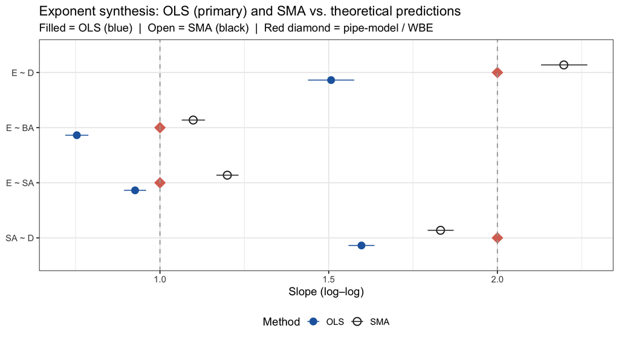

Exponent synthesis: OLS (blue filled, primary) and SMA (black open, secondary) slopes vs. theoretical predictions (red diamond). OLS slopes are attenuated relative to SMA; the true exponent lies between OLS and SMA when both axes carry measurement error.

```r
synth_df <- bind_rows(
  tibble(
    relationship = factor(
      c("E ~ D", "E ~ BA", "E ~ SA", "SA ~ D"),
      levels = c("SA ~ D", "E ~ SA", "E ~ BA", "E ~ D")
    ),
    slope  = c(coef(fit_ols_dbh)["log_dbh"],
               coef(fit_ols_ba)["log_ba"],
               coef(fit_ols_sa)["log_sa"],
               coef(fit_ols_sadbh)["log_dbh"]),
    ci_lo  = c(ols_ci_val(fit_ols_dbh,  "log_dbh", 1),
               ols_ci_val(fit_ols_ba,   "log_ba",  1),
               ols_ci_val(fit_ols_sa,   "log_sa",  1),
               ols_ci_val(fit_ols_sadbh,"log_dbh", 1)),
    ci_hi  = c(ols_ci_val(fit_ols_dbh,  "log_dbh", 2),
               ols_ci_val(fit_ols_ba,   "log_ba",  2),
               ols_ci_val(fit_ols_sa,   "log_sa",  2),
               ols_ci_val(fit_ols_sadbh,"log_dbh", 2)),
    theory = c(2.0, 1.0, 1.0, 2.0),
    method = "OLS"
  ),
  tibble(
    relationship = factor(
      c("E ~ D", "E ~ BA", "E ~ SA", "SA ~ D"),
      levels = c("SA ~ D", "E ~ SA", "E ~ BA", "E ~ D")
    ),
    slope  = c(coef(fit_dbh)[2],   coef(fit_ba)[2],
               coef(fit_sa)[2],    coef(fit_sadbh)[2]),
    ci_lo  = c(fit_dbh$coef[[1]][2,2],   fit_ba$coef[[1]][2,2],
               fit_sa$coef[[1]][2,2],    fit_sadbh$coef[[1]][2,2]),
    ci_hi  = c(fit_dbh$coef[[1]][2,3],   fit_ba$coef[[1]][2,3],
               fit_sa$coef[[1]][2,3],    fit_sadbh$coef[[1]][2,3]),
    theory = c(2.0, 1.0, 1.0, 2.0),
    method = "SMA"
  )
)

ggplot(synth_df,
       aes(y = relationship, x = slope, xmin = ci_lo, xmax = ci_hi,
           colour = method, shape = method)) +
  geom_pointrange(size = 0.9,
                  position = position_dodge(width = 0.55)) +
  geom_point(aes(x = theory, y = relationship), shape = 18, size = 6,
             colour = "#d6604d", alpha = 0.9,
             inherit.aes = FALSE,
             data = distinct(synth_df, relationship, theory)) +
  geom_vline(xintercept = c(1.0, 2.0), linetype = "dashed",
             colour = "grey65", linewidth = 0.6) +
  scale_colour_manual(values = c(OLS = "#2166ac", SMA = "#333333"),
                      name = "Method") +
  scale_shape_manual(values = c(OLS = 16, SMA = 21), name = "Method") +
  labs(
    x = "Slope (log\u2013log)",
    y = NULL,
    title = "Exponent synthesis: OLS (primary) and SMA vs. theoretical predictions",
    subtitle = "Filled = OLS (blue)  |  Open = SMA (black)  |  Red diamond = pipe-model / WBE"
  ) +
  theme_bw(base_size = 13) +
  theme(legend.position = "bottom")
```

# 12 Multi-level structure: site effects

```r
# ── Join site metadata (si_mat, si_map, si_biome, si_country) to dat ─────────
# Required by all subsequent advanced sections.
# Real data:  left_join on si_code from site_md.

if (!is.null(site_md) &&
    "si_code" %in% names(dat) &&
    !"si_mat" %in% names(dat)) {

  dat <- dat |>
    left_join(
      site_md |>
        select(si_code, si_biome, si_country, si_mat, si_map) |>
        distinct(si_code, .keep_all = TRUE),
      by = "si_code"
    )
  cat("Site metadata joined: si_mat, si_map, si_biome, si_country added.\n",
      "Trees with si_mat:", sum(!is.na(dat$si_mat)), "\n")

} else {
  cat("Site columns already present in dat or site_md unavailable.\n")
}
```

```
## Site metadata joined: si_mat, si_map, si_biome, si_country added.
##  Trees with si_mat: 2092
```

```r
cat("Columns now in dat: ",
    paste(intersect(c("si_code","si_biome","si_mat","si_map"),
                    names(dat)), collapse = ", "), "\n")
```

```
## Columns now in dat:  si_code, si_biome, si_mat, si_map
```

```r
# ── Variance decomposition and ICC ───────────────────────────────────────────
# LMM: log(E) ~ log(DBH) + (1 | site)
# Random intercept absorbs site-level hydraulic baseline differences.

if ("si_code" %in% names(dat)) {

  lmm_dbh <- lmer(log_e ~ log_dbh + (1 | si_code),
                  data = dat, REML = TRUE)

  # Variance components
  vc <- as.data.frame(VarCorr(lmm_dbh)) |>
    select(grp, var1, vcov) |>
    rename(Source = grp, Component = var1, Variance = vcov) |>
    mutate(
      `Std. Dev.`  = round(sqrt(Variance), 4),
      Variance     = round(Variance, 4),
      `% of total` = round(100 * Variance / sum(Variance), 1)
    )
  kable(vc,
        caption = "Variance components: log(E) ~ log(DBH) + (1 | site)")

  # ICC: proportion of variance attributable to among-site differences
  icc_res <- icc(lmm_dbh)
  cat("\nICC (proportion of total variance from among-site differences):\n")
  print(icc_res)

  # Fixed-effect slope from LMM vs SMA
  fe <- fixef(lmm_dbh)
  ci_fe <- confint(lmm_dbh, parm = "log_dbh",
                   method = "Wald", quiet = TRUE)
  cat(sprintf(
    "\nLMM fixed slope: %.3f  (95%% Wald CI: %.3f \u2013 %.3f)\n",
    fe["log_dbh"], ci_fe[1], ci_fe[2]
  ))
  cat(sprintf(
    "SMA slope (pooled): %.3f  (95%% CI: %.3f \u2013 %.3f)\n",
    coef(fit_dbh)[2],
    fit_dbh$coef[[1]][2,2],
    fit_dbh$coef[[1]][2,3]
  ))

} else {
  cat("si_code not in dat \u2014 skipping LMM\n")
}
```

```
##
## ICC (proportion of total variance from among-site differences):
## # Intraclass Correlation Coefficient
##
##     Adjusted ICC: 0.763
##   Unadjusted ICC: 0.377
##
## LMM fixed slope: 1.756  (95% Wald CI: 1.701 – 1.811)
## SMA slope (pooled): 2.197  (95% CI: 2.129 – 2.266)
```

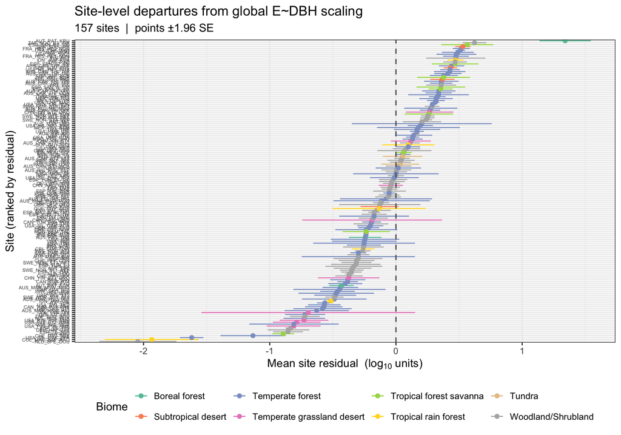

Site-level mean deviations from the overall SMA E~DBH fitted line (caterpillar plot). Large positive residuals = sites with higher water use than the global scaling predicts at a given DBH; points coloured by biome.

```r
# Residuals are computable for all trees regardless of site structure
dat$resid_sma_dbh <- dat$log_e -
  (coef(fit_dbh)[1] + coef(fit_dbh)[2] * dat$log_dbh)

if ("si_code" %in% names(dat)) {
  site_resid_df <- dat |>
    group_by(si_code) |>
    summarise(
      mean_resid = mean(resid_sma_dbh, na.rm = TRUE),
      se_resid   = sd(resid_sma_dbh, na.rm = TRUE) / sqrt(n()),
      n_trees    = n(),
      si_biome   = first(si_biome),
      .groups = "drop"
    ) |>
    filter(!is.na(mean_resid))

  ggplot(site_resid_df,
         aes(x = mean_resid,
             y = reorder(si_code, mean_resid),
             colour = si_biome)) +
    geom_pointrange(
      aes(xmin = mean_resid - 1.96 * se_resid,
          xmax = mean_resid + 1.96 * se_resid),
      size = 0.35, linewidth = 0.6
    ) +
    geom_vline(xintercept = 0, linetype = "dashed",
               colour = "grey40", linewidth = 0.7) +
    scale_colour_brewer(palette = "Set2", na.value = "grey60") +
    labs(
      x = expression("Mean site residual  (" * log[10] * " units)"),
      y = "Site (ranked by residual)",
      colour = "Biome",
      title = "Site-level departures from global E~DBH scaling",
      subtitle = sprintf("%d sites  |  points \u00b11.96 SE",
                         nrow(site_resid_df))
    ) +
    theme(
      axis.text.y  = element_text(size = 5.5),
      legend.position = "bottom"
    )
} else {
  cat("si_code not in dat \u2014 skipping site residuals plot\n")
}
```

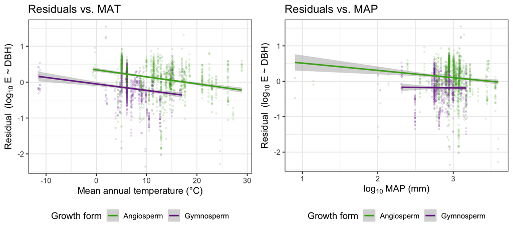

Tree-level residuals from the SMA E~DBH fit vs. mean annual temperature (left) and log10 MAP (right). Systematic trends indicate climate-driven variation in the hydraulic baseline beyond what tree size explains.

```r
if (all(c("si_mat", "si_map", "resid_sma_dbh") %in% names(dat))) {

  dat_env <- dat |> filter(!is.na(si_mat), !is.na(si_map))

  p_mat <- ggplot(dat_env,
                  aes(x = si_mat, y = resid_sma_dbh,
                      colour = growth_form)) +
    geom_point(alpha = 0.12, size = 0.8) +
    geom_smooth(method = "lm", se = TRUE, linewidth = 1.0) +
    scale_colour_manual(
      values = c(Angiosperm = "#4dac26", Gymnosperm = "#7b3294")
    ) +
    labs(
      x = "Mean annual temperature (\u00b0C)",
      y = expression("Residual  (" * log[10] * " E ~ DBH)"),
      colour = "Growth form",
      title = "Residuals vs. MAT"
    ) +
    theme(legend.position = "bottom")

  p_map <- ggplot(dat_env,
                  aes(x = log10(si_map), y = resid_sma_dbh,
                      colour = growth_form)) +
    geom_point(alpha = 0.12, size = 0.8) +
    geom_smooth(method = "lm", se = TRUE, linewidth = 1.0) +
    scale_colour_manual(
      values = c(Angiosperm = "#4dac26", Gymnosperm = "#7b3294")
    ) +
    labs(
      x = expression(log[10] ~ "MAP (mm)"),
      y = expression("Residual  (" * log[10] * " E ~ DBH)"),
      colour = "Growth form",
      title = "Residuals vs. MAP"
    ) +
    theme(legend.position = "bottom")

  gridExtra::grid.arrange(p_mat, p_map, ncol = 2)

} else {
  cat("Climate variables or residuals not available.\n")
}
```

# 13 Biome-stratified scaling

Slopes that vary across biomes reveal ecological contexts where the pipe model or WBE predictions break down. Colder or drier biomes may show lower normalization constants ($k_{SA}$) due to lower leaf-area-to-sapwood ratios or colder xylem conductance.

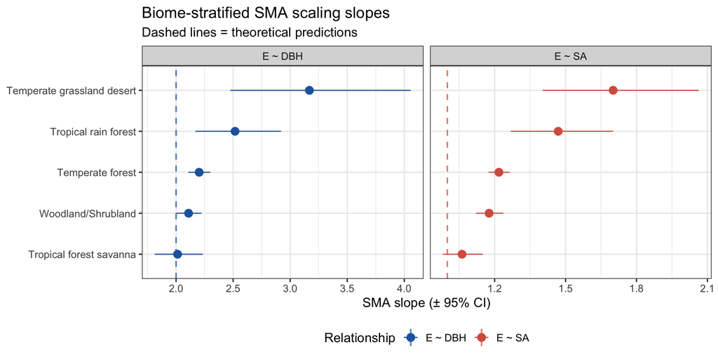

Biome-stratified SMA slopes for E~DBH and E~SA (biomes with ≥20 trees). Dashed lines mark the theoretical predictions. Biomes whose CI excludes the theoretical value deviate significantly from the pipe-model / WBE prediction.

```r
biome_sma <- NULL   # initialise so hydro-norm can check existence

if ("si_biome" %in% names(dat)) {

  biome_sma <- dat |>
    filter(!is.na(si_biome)) |>
    tidyr::nest(data = -si_biome) |>
    mutate(
      n    = map_int(data, nrow),
      n_sp = map_int(data, ~ n_distinct(.x$pl_species, na.rm = TRUE)),
      fit_dbh = map(data, ~ {
        if (nrow(.x) < 20 || n_distinct(.x$pl_species, na.rm=TRUE) < 3) return(NULL)
        tryCatch(sma(log_e ~ log_dbh, data = .x, method = "SMA"),
                 error = function(e) NULL)
      }),
      fit_sa = map(data, ~ {
        if (nrow(.x) < 20 || n_distinct(.x$pl_species, na.rm=TRUE) < 3) return(NULL)
        tryCatch(sma(log_e ~ log_sa,  data = .x, method = "SMA"),
                 error = function(e) NULL)
      }),
      slope_dbh    = map_dbl(fit_dbh,
                             ~ if (is.null(.x)) NA_real_ else coef(.x)[2]),
      ci_lo_dbh    = map_dbl(fit_dbh,
                             ~ if (is.null(.x)) NA_real_ else .x$coef[[1]][2,2]),
      ci_hi_dbh    = map_dbl(fit_dbh,
                             ~ if (is.null(.x)) NA_real_ else .x$coef[[1]][2,3]),
      slope_sa     = map_dbl(fit_sa,
                             ~ if (is.null(.x)) NA_real_ else coef(.x)[2]),
      ci_lo_sa     = map_dbl(fit_sa,
                             ~ if (is.null(.x)) NA_real_ else .x$coef[[1]][2,2]),
      ci_hi_sa     = map_dbl(fit_sa,
                             ~ if (is.null(.x)) NA_real_ else .x$coef[[1]][2,3]),
      intercept_sa = map_dbl(fit_sa,
                             ~ if (is.null(.x)) NA_real_ else coef(.x)[1])
    )

  forest_biome <- bind_rows(
    biome_sma |>
      filter(!is.na(slope_dbh)) |>
      transmute(si_biome, n,
                slope = slope_dbh, ci_lo = ci_lo_dbh, ci_hi = ci_hi_dbh,
                metric = "E ~ DBH", theory = 2.0),
    biome_sma |>
      filter(!is.na(slope_sa)) |>
      transmute(si_biome, n,
                slope = slope_sa,  ci_lo = ci_lo_sa,  ci_hi = ci_hi_sa,
                metric = "E ~ SA",  theory = 1.0)
  )

  ggplot(forest_biome,
         aes(y = reorder(si_biome, slope),
             x = slope, xmin = ci_lo, xmax = ci_hi,
             colour = metric)) +
    geom_pointrange(position = position_dodge(width = 0.55), size = 0.7) +
    geom_vline(data = distinct(forest_biome, metric, theory),
               aes(xintercept = theory, colour = metric),
               linetype = "dashed", linewidth = 0.7, alpha = 0.75) +
    scale_colour_manual(
      values = c("E ~ DBH" = "#2166ac", "E ~ SA" = "#d6604d")
    ) +
    facet_wrap(~ metric, scales = "free_x") +
    labs(
      x = "SMA slope (\u00b1 95% CI)",
      y = NULL,
      colour = "Relationship",
      title = "Biome-stratified SMA scaling slopes",
      subtitle = "Dashed lines = theoretical predictions"
    ) +
    theme(legend.position = "bottom")

} else {
  cat("si_biome not in dat \u2014 skipping biome-stratified SMA\n")
}
```

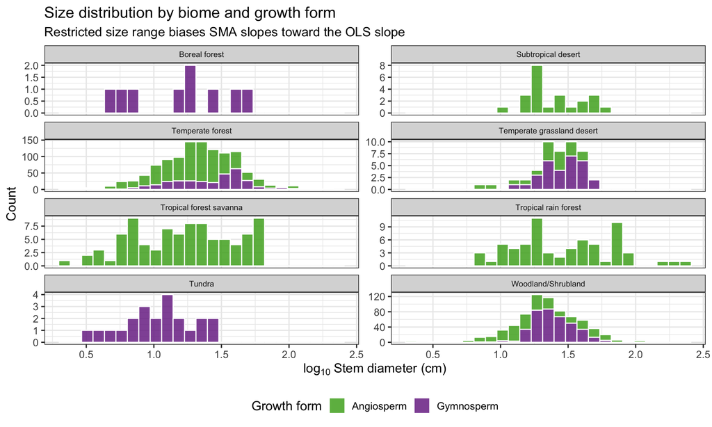

Size distribution (log10 DBH) by biome and growth form. Biomes with truncated large-tree distributions may show artefactually lower slopes due to restricted size range.

```r
if ("si_biome" %in% names(dat)) {
  dat |>
    filter(!is.na(si_biome)) |>
    ggplot(aes(x = log_dbh, fill = growth_form)) +
    geom_histogram(bins = 25, colour = "white", alpha = 0.85,
                   position = "stack") +
    facet_wrap(~ si_biome, scales = "free_y", ncol = 2) +
    scale_fill_manual(
      values = c(Angiosperm = "#4dac26", Gymnosperm = "#7b3294")
    ) +
    labs(
      x = expression(log[10] ~ "Stem diameter (cm)"),
      y = "Count",
      fill = "Growth form",
      title = "Size distribution by biome and growth form",
      subtitle = "Restricted size range biases SMA slopes toward the OLS slope"
    ) +
    theme(strip.text = element_text(size = 8),
          legend.position = "bottom")
} else {
  cat("si_biome not in dat \u2014 skipping size distribution\n")
}
```

# 14 Climate modulation of scaling intercepts

The SMA intercept for $E \sim S_A$ is the log-scale metabolic normalisation constant. If the intercept varies across sites with mean annual temperature (MAT) or precipitation (MAP), it means $k_{SA}$ — the effective sap flux density — shifts with climate independently of tree size. This is tested by averaging SMA residuals at the site level and regressing them against site climate variables.

```
## Sites entering climate model: 148
##
## === LM: site intercept ~ MAT + log10(MAP) [weighted by n trees] ===
##
## Call:
## lm(formula = intercept_i ~ si_mat + log10(si_map), data = site_intercepts,
##     weights = n_trees)
##
## Weighted Residuals:
##     Min      1Q  Median      3Q     Max
## -5.6899 -0.9109  0.2393  0.8373  3.6901
##
## Coefficients:
##                Estimate Std. Error t value Pr(>|t|)
## (Intercept)    0.267431   0.475775   0.562    0.575
## si_mat        -0.002954   0.005699  -0.518    0.605
## log10(si_map) -0.081530   0.171435  -0.476    0.635
##
## Residual standard error: 1.311 on 145 degrees of freedom
## Multiple R-squared:  0.007457,   Adjusted R-squared:  -0.006233
## F-statistic: 0.5447 on 2 and 145 DF,  p-value: 0.5812
```

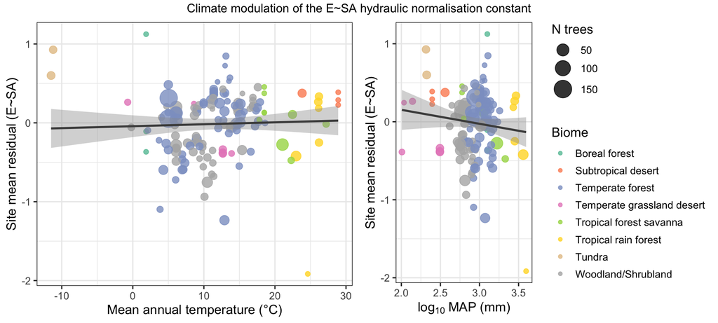

```r
# Residuals from the global E~SA SMA fit
dat$resid_sa <- dat$log_e -
  (coef(fit_sa)[1] + coef(fit_sa)[2] * dat$log_sa)

if (all(c("si_code", "si_mat", "si_map") %in% names(dat))) {

  site_intercepts <- dat |>
    filter(!is.na(si_code), !is.na(resid_sa)) |>
    group_by(si_code) |>
    summarise(
      intercept_i = mean(resid_sa, na.rm = TRUE),
      n_trees     = n(),
      si_mat      = first(si_mat),
      si_map      = first(si_map),
      si_biome    = first(si_biome),
      .groups = "drop"
    ) |>
    filter(!is.na(si_mat), !is.na(si_map), n_trees >= 3)

  cat("Sites entering climate model:", nrow(site_intercepts), "\n")

  # Weighted LM: site intercept deviation ~ MAT + log10(MAP)
  # Weights = number of trees per site (more trees = more reliable mean residual)
  lm_clim <- lm(intercept_i ~ si_mat + log10(si_map),
                data    = site_intercepts,
                weights = n_trees)
  cat("\n=== LM: site intercept ~ MAT + log10(MAP) [weighted by n trees] ===\n")
  print(summary(lm_clim))

  p_mat2 <- ggplot(site_intercepts,
                   aes(x = si_mat, y = intercept_i,
                       colour = si_biome, size = n_trees)) +
    geom_point(alpha = 0.8) +
    geom_smooth(aes(x = si_mat, y = intercept_i),
                method = "lm", se = TRUE, colour = "grey30",
                linewidth = 1.0, inherit.aes = FALSE) +
    scale_colour_brewer(palette = "Set2", na.value = "grey60") +
    scale_size_continuous(range = c(2, 8)) +
    labs(
      x = "Mean annual temperature (\u00b0C)",
      y = "Site mean residual (E~SA)",
      colour = "Biome",
      size = "N trees"
    ) +
    theme(legend.position = "none")

  p_map2 <- ggplot(site_intercepts,
                   aes(x = log10(si_map), y = intercept_i,
                       colour = si_biome, size = n_trees)) +
    geom_point(alpha = 0.8) +
    geom_smooth(aes(x = log10(si_map), y = intercept_i),
                method = "lm", se = TRUE, colour = "grey30",
                linewidth = 1.0, inherit.aes = FALSE) +
    scale_colour_brewer(palette = "Set2", na.value = "grey60") +
    scale_size_continuous(range = c(2, 8)) +
    labs(
      x = expression(log[10] ~ "MAP (mm)"),
      y = "Site mean residual (E~SA)",
      colour = "Biome",
      size = "N trees"
    ) +
    theme(legend.position = "right")

  gridExtra::grid.arrange(p_mat2, p_map2, ncol = 2,
    top = "Climate modulation of the E~SA hydraulic normalisation constant")

} else {
  cat("Climate variables not available \u2014 skipping climate intercept analysis\n")
}
```

# 15 Size-range invariance test

A true power law is **scale-invariant**: the slope should not change when the analysis is restricted to different portions of the size distribution. A systematically changing slope across DBH windows is evidence against a single power-law mechanism operating across the full size range.

The quantile regression of sap flux density vs. diameter provides an additional test: if $k_{SA}$ is truly size-independent (pipe model), the slope at every quantile should be near zero.

```r
dat_w <- dat |>
  mutate(
    size_class = factor(
      case_when(
        pl_dbh < 5    ~ "Small (<5 cm)",
        pl_dbh <= 20  ~ "Medium (5\u201320 cm)",
        TRUE          ~ "Large (>20 cm)"
      ),
      levels = c("Small (<5 cm)", "Medium (5\u201320 cm)", "Large (>20 cm)")
    )
  )

window_sma <- dat_w |>
  tidyr::nest(data = -size_class) |>
  mutate(
    n       = map_int(data, nrow),
    dbh_min = map_dbl(data, ~ min(.x$pl_dbh, na.rm = TRUE)),
    dbh_max = map_dbl(data, ~ max(.x$pl_dbh, na.rm = TRUE)),
    fit     = map(data, ~ {
      if (nrow(.x) < 10) return(NULL)
      tryCatch(sma(log_e ~ log_dbh, data = .x, method = "SMA"),
               error = function(e) NULL)
    }),
    slope  = map_dbl(fit, ~ if (is.null(.x)) NA_real_ else coef(.x)[2]),
    ci_lo  = map_dbl(fit, ~ if (is.null(.x)) NA_real_ else .x$coef[[1]][2,2]),
    ci_hi  = map_dbl(fit, ~ if (is.null(.x)) NA_real_ else .x$coef[[1]][2,3]),
    r2     = map_dbl(fit, ~ if (is.null(.x)) NA_real_ else .x$r2[[1]])
  )

kable(
  window_sma |>
    select(size_class, n, dbh_min, dbh_max, slope, ci_lo, ci_hi, r2) |>
    mutate(across(c(dbh_min, dbh_max, slope, ci_lo, ci_hi, r2),
                  ~ round(.x, 3))) |>
    rename(
      `Size class`  = size_class,
      N             = n,
      `DBH min (cm)` = dbh_min,
      `DBH max (cm)` = dbh_max,
      `SMA slope`   = slope,
      `CI low`      = ci_lo,
      `CI high`     = ci_hi,
      `R2`          = r2
    ),
  caption = "SMA slope for E~DBH within each DBH size window (scale-invariance test)"
)
```

SMA slope for E~DBH within each DBH size window (scale-invariance test)

| Size class | N | DBH min (cm) | DBH max (cm) | SMA slope | CI low | CI high | R2 |
| --- | --- | --- | --- | --- | --- | --- | --- |
| Large (>20 cm) | 1170 | 20.02 | 220.0 | 2.960 | 2.810 | 3.117 | 0.186 |
| Medium (5–20 cm) | 889 | 5.00 | 20.0 | 3.280 | 3.097 | 3.475 | 0.237 |
| Small (<5 cm) | 33 | 2.05 | 4.9 | 3.397 | 2.470 | 4.672 | 0.217 |

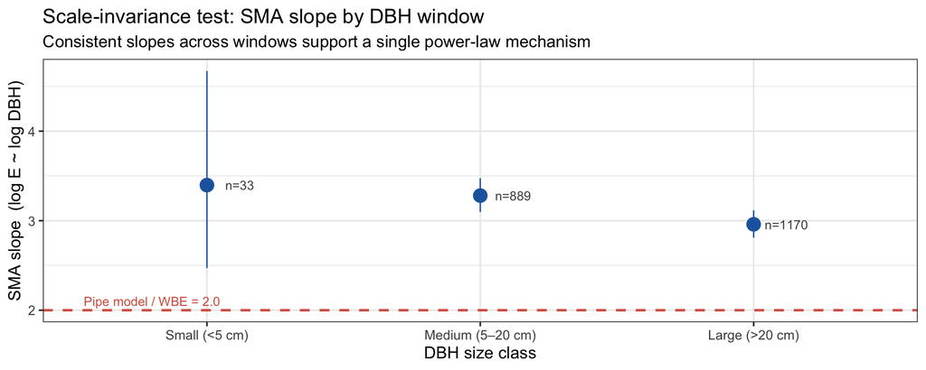

Scale-invariance test: SMA slope for E~DBH within three non-overlapping DBH windows. If the power law is scale-invariant, slopes should be statistically indistinguishable from each other and consistent with the theoretical value of 2.0 (red dashed line).

```r
ggplot(window_sma |> filter(!is.na(slope)),
       aes(x = size_class, y = slope, ymin = ci_lo, ymax = ci_hi)) +
  geom_hline(yintercept = 2.0, linetype = "dashed",
             colour = "#d6604d", linewidth = 0.9) +
  geom_pointrange(colour = "#2166ac", size = 1.0) +
  geom_text(aes(label = paste0("n=", n)),
            nudge_x = 0.12, size = 3.5, colour = "grey30") +
  annotate("text", x = 0.55, y = 2.0, label = "Pipe model / WBE = 2.0",
           vjust = -0.5, hjust = 0, colour = "#d6604d", size = 3.5) +
  labs(
    x = "DBH size class",
    y = "SMA slope  (log E ~ log DBH)",
    title = "Scale-invariance test: SMA slope by DBH window",
    subtitle = "Consistent slopes across windows support a single power-law mechanism"
  )
```

```r
# Pipe-model invariance: SFD should be size-independent
dat_sfd_qr <- dat |>
  mutate(log_sfd = log10(e_tree / pl_sapw_area)) |>
  filter(is.finite(log_sfd), !is.na(log_dbh))

taus <- c(0.10, 0.50, 0.90)
qr_fits <- lapply(taus, function(tau) {
  rq(log_sfd ~ log_dbh, data = dat_sfd_qr, tau = tau)
})
names(qr_fits) <- paste0("tau=", taus)

# Coefficient table (sandwich SE, computationally inexpensive)
qr_coef_rows <- lapply(names(qr_fits), function(nm) {
  s    <- summary(qr_fits[[nm]], se = "nid")
  cmat <- as.data.frame(s$coefficients)
  tibble(
    Quantile  = nm,
    Term      = rownames(cmat),
    Estimate  = cmat[[1]],
    `Std. Error` = cmat[[2]],
    `t value` = cmat[[3]],
    `p value` = cmat[[4]]
  )
})
qr_table <- bind_rows(qr_coef_rows) |>
  filter(Term == "log_dbh") |>
  select(-Term) |>
  mutate(across(where(is.numeric), ~ round(.x, 4)))

kable(qr_table,
      caption = "Quantile regression: log(SFD) ~ log(DBH) — slope at 10th, 50th, 90th percentile")
```

Quantile regression: log(SFD) ~ log(DBH) — slope at 10th, 50th, 90th percentile

| Quantile | Estimate | Std. Error | t value | p value |
| --- | --- | --- | --- | --- |
| tau=0.1 | -0.2066 | 0.0665 | -3.1081 | 0.0019 |
| tau=0.5 | -0.0862 | 0.0336 | -2.5665 | 0.0103 |
| tau=0.9 | 0.0477 | 0.0357 | 1.3355 | 0.1819 |

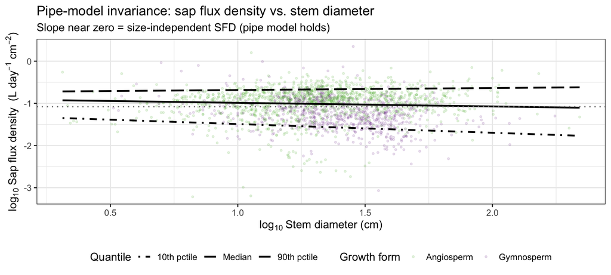

Quantile regression of log sap flux density (SFD = E/SA) vs. log stem diameter at the 10th, 50th, and 90th percentiles. Slopes near zero at all quantiles support size-independence of SFD (pipe model null). Non-zero slope at the 90th percentile but not the median would indicate that only the largest trees deviate.

```r
# Prediction lines
dbh_seq  <- seq(min(dat_sfd_qr$log_dbh), max(dat_sfd_qr$log_dbh),
                length.out = 200)
qr_lines <- lapply(names(qr_fits), function(nm) {
  cf <- coef(qr_fits[[nm]])
  tibble(
    log_dbh  = dbh_seq,
    log_sfd  = cf[1] + cf[2] * dbh_seq,
    quantile = nm
  )
}) |> bind_rows()

ggplot(dat_sfd_qr, aes(x = log_dbh, y = log_sfd)) +
  geom_point(aes(colour = growth_form), alpha = 0.14, size = 0.9) +
  geom_line(data  = qr_lines,
            aes(x = log_dbh, y = log_sfd,
                linetype = quantile, group = quantile),
            colour = "black", linewidth = 1.0) +
  geom_hline(yintercept = mean(dat_sfd_qr$log_sfd, na.rm = TRUE),
             linetype = "dotted", colour = "grey50", linewidth = 0.7) +
  scale_colour_manual(
    values = c(Angiosperm = "#4dac26", Gymnosperm = "#7b3294")
  ) +
  scale_linetype_manual(
    values = c("tau=0.1"  = "dotdash",
               "tau=0.5"  = "solid",
               "tau=0.9"  = "longdash"),
    labels = c("tau=0.1"  = "10th pctile",
               "tau=0.5"  = "Median",
               "tau=0.9"  = "90th pctile")
  ) +
  labs(
    x        = expression(log[10] ~ "Stem diameter (cm)"),
    y        = expression(log[10] ~ "Sap flux density  (L day" ^ {-1} ~ cm ^ {-2} * ")"),
    colour   = "Growth form",
    linetype = "Quantile",
    title    = "Pipe-model invariance: sap flux density vs. stem diameter",
    subtitle = "Slope near zero = size-independent SFD (pipe model holds)"
  ) +
  theme(legend.position = "bottom")
```

# 16 Hydraulic normalization constants

The antilog of the SMA intercept from $\log E = b_0 + b_1 \log S_A$ gives

$$k_{SA} = 10^{b_0} \quad [\text{L
day}^{-1}\,\text{cm}^{-2}]$$

This is the **effective sap flux density** — the average water throughput per unit sapwood cross-section. It is a physiologically interpretable quantity that varies with stomatal conductance regime, hydraulic architecture, and atmospheric demand. Differences across biomes and functional types represent climatic and anatomical modulation of the normalization constant that is otherwise invisible in slope-only comparisons.

```r
# ── Global normalisation constant ─────────────────────────────────────────────
hyd_norm_global <- 10^coef(fit_sa)[1]
cat(sprintf(
  "Global k_SA: 10^%.4f = %.4f L day\u207b\u00b9 cm\u207b\u00b2\n",
  coef(fit_sa)[1], hyd_norm_global
))
```

```
## Global k_SA: 10^-1.5363 = 0.0291 L day⁻¹ cm⁻²
```

```r
# ── By growth form (from gf_fits; metric == 'SA') ─────────────────────────────
hyd_norm_gf <- gf_fits |>
  filter(metric == "SA", !is.na(slope)) |>
  rowwise() |>
  mutate(
    intercept = if (!is.null(fit)) coef(fit)[1] else NA_real_,
    hyd_norm  = 10^intercept
  ) |>
  ungroup() |>
  select(growth_form, n, intercept, hyd_norm, slope, ci_lo, ci_hi)

kable(
  hyd_norm_gf |>
    mutate(across(where(is.numeric), ~ round(.x, 4))) |>
    rename(
      `Growth form`     = growth_form,
      N                 = n,
      `log10(k_SA)`     = intercept,
      `k_SA (L/d/cm2)` = hyd_norm,
      `E~SA slope`      = slope,
      `CI low`          = ci_lo,
      `CI high`         = ci_hi
    ),
  caption = "Hydraulic normalisation constant k_SA by growth form"
)
```

Hydraulic normalisation constant k_SA by growth form

[output not shown]

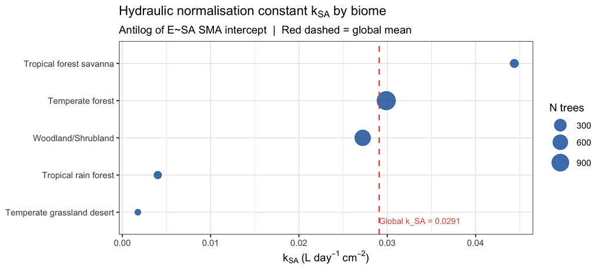

Hydraulic normalization constant k_SA (= 10^intercept from E~SA SMA) by growth form (table) and biome (dot plot). Red dashed line = global mean k_SA. Biomes above the line maintain higher sap flux density per unit sapwood area.

```r
# ── By biome (from biome_sma) ─────────────────────────────────────────────────
if (!is.null(biome_sma) && "intercept_sa" %in% names(biome_sma)) {

  hyd_norm_biome <- biome_sma |>
    filter(!is.na(intercept_sa)) |>
    mutate(hyd_norm = 10^intercept_sa) |>
    select(si_biome, n, intercept_sa, hyd_norm,
           slope_sa, ci_lo_sa, ci_hi_sa) |>
    arrange(desc(hyd_norm))

  kable(
    hyd_norm_biome |>
      mutate(across(where(is.numeric), ~ round(.x, 4))) |>
      rename(
        Biome                = si_biome,
        N                    = n,
        `log10(k_SA)`        = intercept_sa,
        `k_SA (L/d/cm2)`    = hyd_norm,
        `E~SA slope`         = slope_sa,
        `CI low (slope)`     = ci_lo_sa,
        `CI high (slope)`    = ci_hi_sa
      ),
    caption = paste0(
      "Hydraulic normalisation constant k_SA by biome. ",
      "k_SA = 10^(SMA intercept for E~SA) is interpretable as effective ",
      "hydraulic conductance per unit sapwood area (L day\u207b\u00b9 cm\u207b\u00b2) ",
      "ONLY when the E~SA slope does not significantly depart from 1.0. ",
      "For biomes where CI does not include 1.0, treat k_SA as the fitted ",
      "value at SA = 1 cm\u00b2, not a size-independent hydraulic constant."
    )
  )

  ggplot(hyd_norm_biome,
         aes(x = reorder(si_biome, hyd_norm),
             y = hyd_norm, size = n)) +
    geom_point(colour = "#2166ac", alpha = 0.85) +
    geom_hline(yintercept = hyd_norm_global,
               linetype = "dashed", colour = "#d6604d",
               linewidth = 0.8) +
    annotate("text",
             x     = 0.6,
             y     = hyd_norm_global,
             label = sprintf("Global k_SA = %.4f", hyd_norm_global),
             vjust = -0.55, hjust = 0, size = 3.5, colour = "#d6604d") +
    coord_flip() +
    scale_size_continuous(range = c(3, 10)) +
    labs(
      x        = NULL,
      y        = expression(k[SA] ~ "(L day" ^ {-1} ~ cm ^ {-2} * ")"),
      size     = "N trees",
      title    = expression("Hydraulic normalisation constant " * k[SA] * " by biome"),
      subtitle = "Antilog of E~SA SMA intercept  |  Red dashed = global mean"
    ) +
    theme(legend.position = "right")

} else {
  cat("biome_sma not available \u2014 run the biome-stratified SMA section first\n")
}
```

# 17 Regression method comparison: OLS (primary), SMA, and PGLS

This section consolidates OLS (Model I), standardised major axis regression (SMA, Model II / RMA), and phylogenetic generalised least squares (PGLS) slopes for all three core scaling relationships ($E \sim D$, $E \sim BA$, $E \sim SA$).

**OLS (Model I)** minimises residuals in the response ($y$) direction only; it is the appropriate estimator for prediction and hypothesis testing about the conditional mean but is attenuated toward zero when the predictor carries measurement error. **SMA (Model II / RMA)** minimises residuals symmetrically and is often preferred for allometric log–log relationships where both axes carry error; it provides the slope of the major axis of the bivariate distribution and is always ≥ the OLS slope in magnitude. **PGLS** operates on species means and adjusts for shared evolutionary history via a Pagel $\lambda$ covariance structure estimated by maximum likelihood. $\lambda = 1$ = Brownian-motion covariance; $\lambda = 0$ = star phylogeny (equivalent to OLS on species means).

```r
# Required for this section: V.PhyloMaker2, caper, ape
# (loaded in setup chunk above)

if (USE_REAL_DATA && "pl_species" %in% names(dat)) {

  # Count trees per species
  sp_counts <- dat |>
    filter(!is.na(pl_species), nchar(trimws(pl_species)) > 0) |>
    count(pl_species, name = "n_trees")

  # Parse genus as first word of binomial
  sp_list_raw <- sp_counts |>
    mutate(
      species = pl_species,
      genus   = stringr::word(pl_species, 1)
    )

  # Family lookup from V.PhyloMaker2 species table (LCVP backbone)
  # tips.info.LCVP columns: group, species (Genus_species), genus, family
  tips_lcvp     <- V.PhyloMaker2::tips.info.LCVP
  # Convert backbone species to space format for matching against pl_species
  tips_sp_space <- gsub("_", " ", tips_lcvp$species)

  # W1 fix: species-level family lookup first, fall back to genus-level
  # (distinct(genus) can misassign polyphyletic genera — prefer species match)
  sp_family_exact <- tips_lcvp |>
    mutate(species_sp = gsub("_", " ", species)) |>
    select(species_sp, family) |>
    distinct(species_sp, .keep_all = TRUE)

  genus_family <- tips_lcvp |>
    select(genus, family) |>
    distinct(genus, .keep_all = TRUE)

  sp_list <- sp_list_raw |>
    left_join(sp_family_exact, by = c("species" = "species_sp")) |>
    left_join(genus_family,    by = "genus", suffix = c("", "_genus")) |>
    mutate(
      family       = coalesce(family, family_genus, "Unknown"),
      match_status = case_when(
        species %in% tips_sp_space     ~ "matched",
        genus   %in% tips_lcvp$genus   ~ "genus_only",
        TRUE                            ~ "unmatched"
      )
    ) |>
    select(-family_genus)

  n_total      <- nrow(sp_list)
  n_matched    <- sum(sp_list$match_status == "matched")
  n_genus_only <- sum(sp_list$match_status == "genus_only")
  n_unmatched  <- sum(sp_list$match_status == "unmatched")

  cat(sprintf(
    "Taxonomy reconciliation \u2014 %d species total\n  matched: %d (%.1f%%)\n  genus-only: %d (%.1f%%)\n  unmatched: %d (%.1f%%)\n",
    n_total,
    n_matched,    100 * n_matched    / n_total,
    n_genus_only, 100 * n_genus_only / n_total,
    n_unmatched,  100 * n_unmatched  / n_total
  ))

  kable(
    sp_list |>
      select(species, genus, family, match_status, n_trees) |>
      arrange(match_status, species) |>
      rename(
        Species        = species,
        Genus          = genus,
        Family         = family,
        `Match status` = match_status,
        `N trees`      = n_trees
      ),
    caption = "Taxonomy reconciliation: SAPFLUXNET species matched to V.PhyloMaker2 LCVP backbone (GBOTB.extended.LCVP). match_status: matched = exact species in backbone; genus_only = genus placed, species absent; unmatched = genus absent. Family assigned at species level first, with genus-level fallback."
  )

} else {
  sp_list <- NULL
  message(
    "Taxonomy reconciliation skipped: requires USE_REAL_DATA = TRUE ",
    "and pl_species column in dat."
  )
}
```

```
## Taxonomy reconciliation — 149 species total
##   matched: 95 (63.8%)
##   genus-only: 49 (32.9%)
##   unmatched: 5 (3.4%)
```

Taxonomy reconciliation: SAPFLUXNET species matched to V.PhyloMaker2 LCVP backbone (GBOTB.extended.LCVP). match_status: matched = exact species in backbone; genus_only = genus placed, species absent; unmatched = genus absent. Family assigned at species level first, with genus-level fallback.

| Species | Genus | Family | Match status | N trees |
| --- | --- | --- | --- | --- |
| Abrahamia ditimena | Abrahamia | Anacardiaceae | genus_only | 1 |
| Acacia tortilis | Acacia | Fabaceae | genus_only | 9 |
| Alchornea triplinervia | Alchornea | Euphorbiaceae | genus_only | 5 |
| Ampelocera macrocarpa | Ampelocera | Ulmaceae | genus_only | 2 |
| Aspidosperma desmanthum | Aspidosperma | Apocynaceae | genus_only | 1 |
| Betula pubescens subsp. czerepanovii | Betula | Betulaceae | genus_only | 7 |
| Betula sp. | Betula | Betulaceae | genus_only | 2 |
| Carya cordiformis | Carya | Juglandaceae | genus_only | 2 |
| Carya tomentosa | Carya | Juglandaceae | genus_only | 10 |
| Castanopsis acuminatissima | Castanopsis | Fagaceae | genus_only | 8 |
| Clethra macrophylla | Clethra | Clethraceae | genus_only | 3 |
| Cryptocarya laevigata | Cryptocarya | Lauraceae | genus_only | 6 |
| Cupania macrophylla | Cupania | Sapindaceae | genus_only | 1 |
| Eucalyptus globulus | Eucalyptus | Myrtaceae | genus_only | 35 |
| Eucalyptus radiata | Eucalyptus | Myrtaceae | genus_only | 7 |
| Eucalyptus rubida | Eucalyptus | Myrtaceae | genus_only | 5 |
| Eucalyptus tereticornis | Eucalyptus | Myrtaceae | genus_only | 10 |
| Eugenia spp. | Eugenia | Myrtaceae | genus_only | 1 |
| Fagus grandifolia | Fagus | Fagaceae | genus_only | 48 |
| Fagus sylvatica | Fagus | Fagaceae | genus_only | 49 |
| Fraxinus pennsylvanica | Fraxinus | Oleaceae | genus_only | 4 |
| Gymnanthes riparia | Gymnanthes | Euphorbiaceae | genus_only | 3 |
| Inga sp. | Inga | Fabaceae | genus_only | 1 |
| Larix cajanderi | Larix | Pinaceae | genus_only | 22 |
| Larix kaempferi x Larix gmelinii | Larix | Pinaceae | genus_only | 1 |
| Leptolaena spp. | Leptolaena | Sarcolaenaceae | genus_only | 1 |
| Macrolobium costaricense | Macrolobium | Fabaceae | genus_only | 1 |
| Mortoniodendron anisophyllum | Mortoniodendron | Malvaceae | genus_only | 2 |
| Nothofagus cunninghamii | Nothofagus | Nothofagaceae | genus_only | 5 |
| Ocotea samosa | Ocotea | Lauraceae | genus_only | 1 |

[output cut: 119 more lines]

```r
if (USE_REAL_DATA && !is.null(sp_list)) {

  n_unknown        <- sum(sp_list$family == "Unknown")
  sp_list_for_tree <- sp_list |>
    filter(family != "Unknown") |>
    select(species, genus, family) |>
    distinct(species, .keep_all = TRUE)

  cat(sprintf(
    "Building genus-level phylogeny (scenario S3) for %d species\n  (%d species with Unknown family excluded from tree build)\n",
    nrow(sp_list_for_tree), n_unknown
  ))

  set.seed(42)  # reproducible S3 random genus placements
  phy <- tryCatch({
    result <- phylo.maker(
      sp.list        = as.data.frame(sp_list_for_tree),
      tree           = V.PhyloMaker2::GBOTB.extended.LCVP,
      nodes          = V.PhyloMaker2::nodes.info.1.LCVP,
      output.sp.list = FALSE,
      scenarios      = "S3",
      r              = 1
    )
    tree_out <- result$scenario.3
    # caper::comparative.data() fails if node labels duplicate tip labels;
    # V.PhyloMaker2 S3 assigns internal node labels (e.g., 'Spermatophyta')
    # that can duplicate the clade ancestor name. Clearing them is safe.
    tree_out$node.label <- NULL
    tree_out
  }, error = function(e) {
    cat("ERROR: phylo.maker() failed:", conditionMessage(e), "\n")
    NULL
  })

  if (!is.null(phy)) {
    # Zero-length branches destabilize lambda ML optimization; add epsilon floor
    n_zero <- sum(phy$edge.length == 0)
    if (n_zero > 0) {
      cat(sprintf("WARNING: %d zero-length branches found; adding 1e-6 epsilon floor.\n", n_zero))
      phy$edge.length[phy$edge.length == 0] <- 1e-6
    }
    cat(sprintf(
      "Phylogeny built: %d tips | ultrametric: %s | zero-length branches fixed: %d\n",
      length(phy$tip.label), is.ultrametric(phy), n_zero
    ))
  } else {
    cat("Tree build failed \u2014 PGLS sections will be skipped.\n")
  }

} else {
  phy <- NULL
  if (!USE_REAL_DATA) {
    message("Phylogeny build skipped: PGLS requires real SAPFLUXNET species data.")
  }
}
```

```
## Building genus-level phylogeny (scenario S3) for 144 species
##   (5 species with Unknown family excluded from tree build)
## Phylogeny built: 144 tips | ultrametric: TRUE | zero-length branches fixed: 0
```

```r
sp_means   <- NULL
comp_data  <- NULL
phy_pruned <- NULL

if (USE_REAL_DATA && !is.null(phy) && "pl_species" %in% names(dat)) {

  sp_means <- dat |>
    group_by(pl_species, growth_form) |>
    summarise(
      log_e   = mean(log_e,   na.rm = TRUE),
      log_dbh = mean(log_dbh, na.rm = TRUE),
      log_ba  = mean(log_ba,  na.rm = TRUE),
      log_sa  = mean(log_sa,  na.rm = TRUE),
      n       = n(),
      .groups = "drop"
    ) |>
    filter(n >= 3) |>
    mutate(tip_label = gsub(" ", "_", pl_species))

  cat(sprintf("Species means: %d species with >= 3 trees each\n", nrow(sp_means)))

  # V.PhyloMaker2 tip labels use Genus_species (underscore) format
  shared_tips <- intersect(sp_means$tip_label, phy$tip.label)
  cat(sprintf(
    "Species in common with phylogeny tips: %d of %d\n",
    length(shared_tips), nrow(sp_means)
  ))

  if (length(shared_tips) >= 10) {

    phy_pruned <- drop.tip(phy, setdiff(phy$tip.label, shared_tips))
    phy_pruned$node.label <- NULL  # ensure no node-label conflicts after pruning

    sp_means_df <- sp_means |>
      filter(tip_label %in% shared_tips) |>
      as.data.frame()

    comp_data <- tryCatch(
      caper::comparative.data(
        phy          = phy_pruned,
        data         = sp_means_df,
        names.col    = "tip_label",
        vcv          = TRUE,
        warn.dropped = FALSE
      ),
      error = function(e) {
        cat("ERROR: comparative.data() failed:", conditionMessage(e), "\n")
        NULL
      }
    )

    if (!is.null(comp_data)) {
      cat(sprintf(
        "Comparative data object ready: %d species in pruned tree\n",
        length(phy_pruned$tip.label)
      ))
    }

  } else {
    cat(sprintf(
      "Only %d species overlap between data and tree (minimum 10 required) \u2014 PGLS skipped.\n",
      length(shared_tips)
    ))
    sp_means <- sp_means |> filter(tip_label %in% shared_tips)
  }

} else if (!USE_REAL_DATA) {
  cat("PGLS setup skipped: requires real SAPFLUXNET data (USE_REAL_DATA = TRUE).\n")
}
```

```
## Species means: 101 species with >= 3 trees each
## Species in common with phylogeny tips: 100 of 101
## Comparative data object ready: 100 species in pruned tree
```

```r
# ── Per-relationship helper: run OLS + SMA (already fitted) + PGLS ────────────
# Relationships: E~DBH, E~BA, E~SA
# Returns a one-row tibble for the comparison table.

fit_ols         <- NULL   # E~DBH OLS (kept for reg-comparison-plot)
fit_pgls        <- NULL   # E~DBH PGLS (kept for lambda-interpretation)
pgls_lambda_val <- NA_real_
pgls_n          <- NA_integer_

run_pgls_rel <- function(y_col, x_col, comp_d) {
  tryCatch({
    fm  <- as.formula(paste(y_col, "~", x_col))
    fit <- caper::pgls(fm, data = comp_d, lambda = "ML")
    sm  <- summary(fit)
    cm  <- sm$coefficients
    # Guard: ensure x_col appears in coefficient table by name
    if (!x_col %in% rownames(cm)) {
      stop(sprintf("Coefficient '%s' not in PGLS summary. Available: %s",
                   x_col, paste(rownames(cm), collapse = ", ")))
    }
    sl  <- cm[x_col, "Estimate"]
    pv  <- cm[x_col, "Pr(>|t|)"]
    r2  <- sm$r.sq
    lam <- as.numeric(fit$param["lambda"])
    # Use t-distribution CI from confint() — more accurate than +/- 1.96*SE at small n
    sl_ci <- tryCatch(confint(fit)[x_col, ], error = function(e) c(NA_real_, NA_real_))
    lci <- tryCatch({
      ci <- fit$param.CI$lambda
      c(lo = as.numeric(ci[["lower.CI"]]), hi = as.numeric(ci[["upper.CI"]]))
    }, error = function(e) c(lo = NA_real_, hi = NA_real_))
    list(fit = fit, slope = sl, ci_lo = sl_ci[1], ci_hi = sl_ci[2],
         p = pv, r2 = r2, lambda = lam, lambda_lo = lci["lo"], lambda_hi = lci["hi"],
         n = nrow(comp_d$data))
  }, error = function(e) {
    cat(sprintf("ERROR: PGLS failed (%s ~ %s): %s\n", y_col, x_col, conditionMessage(e)))
    NULL
  })
}

if (USE_REAL_DATA && !is.null(sp_means) && nrow(sp_means) >= 10 &&
    !is.null(comp_data)) {

  # ── OLS on all individual trees for each relationship ──────────────────────
  fit_ols     <- lm(log_e ~ log_dbh, data = dat)   # kept for plot below
  fit_ols_ba2 <- lm(log_e ~ log_ba,  data = dat)
  fit_ols_sa2 <- lm(log_e ~ log_sa,  data = dat)

  ols_n <- nrow(dat)
  sma_n <- nrow(dat)

  ols_rows <- list(
    list(rel = "E ~ DBH", x = "log_dbh",
         fit = fit_ols,     sma_fit = fit_dbh,
         ols_ci = confint(fit_ols)["log_dbh", ],
         sma_ci_lo = fit_dbh$coef[[1]][2,2], sma_ci_hi = fit_dbh$coef[[1]][2,3]),
    list(rel = "E ~ BA",  x = "log_ba",
         fit = fit_ols_ba2, sma_fit = fit_ba,
         ols_ci = confint(fit_ols_ba2)["log_ba", ],
         sma_ci_lo = fit_ba$coef[[1]][2,2],  sma_ci_hi = fit_ba$coef[[1]][2,3]),
    list(rel = "E ~ SA",  x = "log_sa",
         fit = fit_ols_sa2, sma_fit = fit_sa,
         ols_ci = confint(fit_ols_sa2)["log_sa", ],
         sma_ci_lo = fit_sa$coef[[1]][2,2],  sma_ci_hi = fit_sa$coef[[1]][2,3])
  )

  # ── PGLS for each relationship ─────────────────────────────────────────────
  pgls_dbh <- run_pgls_rel("log_e", "log_dbh", comp_data)
  pgls_ba  <- run_pgls_rel("log_e", "log_ba",  comp_data)
  pgls_sa  <- run_pgls_rel("log_e", "log_sa",  comp_data)

  # Store primary (E~DBH) PGLS for downstream chunks
  if (!is.null(pgls_dbh)) {
    fit_pgls        <- pgls_dbh$fit
    pgls_lambda_val <- pgls_dbh$lambda
    pgls_n          <- pgls_dbh$n
  }

  # ── Build unified comparison table ────────────────────────────────────────
  make_rows <- function(row_spec, pgls_res, method_prefix = NULL) {
    x_col   <- row_spec$x
    rel     <- row_spec$rel
    sma_summ <- summary(lm(log_e ~ ., data = dat[, c("log_e", x_col)]))  # for SMA p unused
    ols_sl  <- coef(row_spec$fit)[x_col]
    sma_sl  <- coef(row_spec$sma_fit)[2]
    sma_p   <- tryCatch(row_spec$sma_fit$pval[[1]], error = function(e) NA_real_)

    tibble(
      Relationship = rel,
      Method       = c("OLS (all trees)", "SMA / RMA (all trees)", "PGLS (sp. means)"),
      n            = c(ols_n, sma_n, if (!is.null(pgls_res)) pgls_res$n else NA_integer_),
      Slope        = round(c(ols_sl, sma_sl,
                              if (!is.null(pgls_res)) pgls_res$slope else NA_real_), 3),
      CI_low       = round(c(row_spec$ols_ci[1], row_spec$sma_ci_lo,
                              if (!is.null(pgls_res)) pgls_res$ci_lo else NA_real_), 3),
      CI_high      = round(c(row_spec$ols_ci[2], row_spec$sma_ci_hi,
                              if (!is.null(pgls_res)) pgls_res$ci_hi else NA_real_), 3),
      R2           = round(c(summary(row_spec$fit)$r.squared,
                              row_spec$sma_fit$r2[[1]],
                              if (!is.null(pgls_res)) pgls_res$r2 else NA_real_), 3),
      pvalue       = signif(c(
                       summary(row_spec$fit)$coefficients[x_col, "Pr(>|t|)"],
                       sma_p,
                       if (!is.null(pgls_res)) pgls_res$p else NA_real_), 3),
      lambda_ML    = c(NA_real_, NA_real_,
                       if (!is.null(pgls_res)) round(pgls_res$lambda, 3) else NA_real_)
    )
  }

  comp_table_full <- bind_rows(
    make_rows(ols_rows[[1]], pgls_dbh),
    make_rows(ols_rows[[2]], pgls_ba),
    make_rows(ols_rows[[3]], pgls_sa)
  )

  kable(
    comp_table_full,
    col.names = c("Relationship", "Method", "n", "Slope", "CI low", "CI high",
                  "R\u00b2", "p-value", "\u03bb (Pagel)"),
    caption = sprintf(
      "Regression method comparison for E ~ DBH, E ~ BA, and E ~ SA (log-log scale). OLS and SMA use all individual trees (n = %d); PGLS uses species means (n = %d species in pruned phylogeny). Pagel\u2019s \u03bb estimated by ML. OLS is the primary regression (Model I); SMA is Model II (symmetric residuals). PGLS accounts for shared evolutionary history.",
      ols_n, if (!is.null(pgls_dbh)) pgls_dbh$n else NA_integer_
    )
  )

  # Summary of PGLS lambda across relationships
  lambda_summary <- bind_rows(
    if (!is.null(pgls_dbh)) tibble(Relationship="E~DBH", lambda=pgls_dbh$lambda,
                                    lambda_lo=pgls_dbh$lambda_lo, lambda_hi=pgls_dbh$lambda_hi),
    if (!is.null(pgls_ba))  tibble(Relationship="E~BA",  lambda=pgls_ba$lambda,
                                    lambda_lo=pgls_ba$lambda_lo,  lambda_hi=pgls_ba$lambda_hi),
    if (!is.null(pgls_sa))  tibble(Relationship="E~SA",  lambda=pgls_sa$lambda,
                                    lambda_lo=pgls_sa$lambda_lo,  lambda_hi=pgls_sa$lambda_hi)
  )

  cat("\nPagel's lambda (ML) per relationship:\n")
  print(lambda_summary)

} else {
  message(
    "Regression comparison skipped: requires USE_REAL_DATA = TRUE ",
    "and >= 10 species with both data and phylogeny coverage."
  )
}
```

```
##
## Pagel's lambda (ML) per relationship:
## # A tibble: 3 × 4
##   Relationship lambda lambda_lo lambda_hi
##   <chr>         <dbl>     <dbl>     <dbl>
## 1 E~DBH        0.0316        NA        NA
## 2 E~BA         0.0316        NA        NA
## 3 E~SA         0.670         NA        NA
```

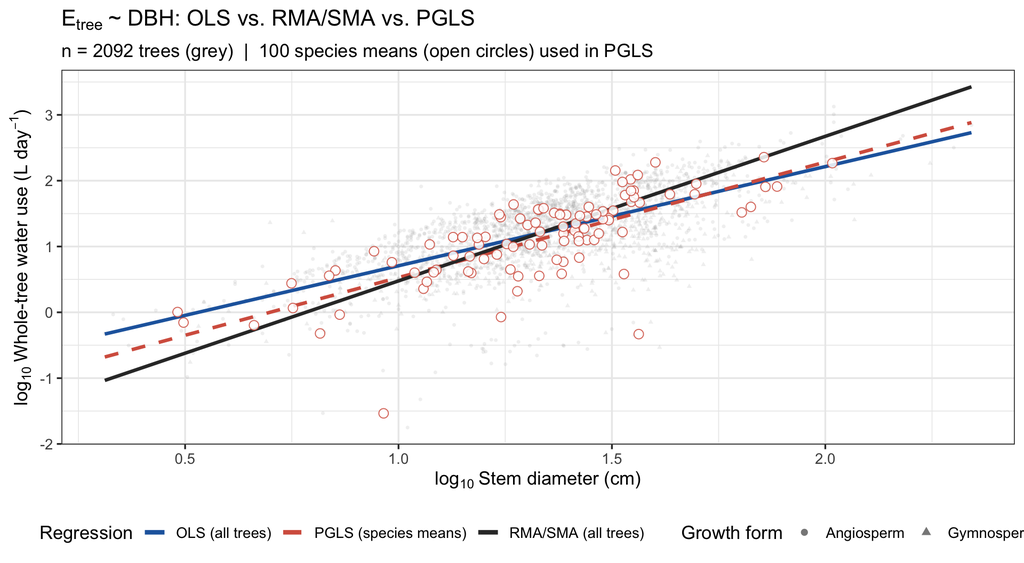

E ~ DBH: OLS (blue solid, primary), SMA (black solid, secondary), PGLS (red dashed, species means). Open circles = species means in PGLS. OLS and SMA use all individual trees; PGLS degrees of freedom = species in the pruned phylogeny.

```r
if (USE_REAL_DATA && !is.null(sp_means) && nrow(sp_means) >= 10 &&
    !is.null(fit_pgls) && !is.null(phy_pruned)) {

  x_rng <- range(dat$log_dbh, na.rm = TRUE)
  x_seq <- seq(x_rng[1], x_rng[2], length.out = 200)

  ols_cf  <- coef(fit_ols)
  sma_cf  <- coef(fit_dbh)
  pgls_cf <- coef(fit_pgls)

  pred_lines <- bind_rows(
    tibble(log_dbh = x_seq,
           log_e   = ols_cf["(Intercept)"] + ols_cf["log_dbh"] * x_seq,
           Method  = "OLS (all trees)"),
    tibble(log_dbh = x_seq,
           log_e   = sma_cf[1] + sma_cf[2] * x_seq,
           Method  = "RMA/SMA (all trees)"),
    tibble(log_dbh = x_seq,
           log_e   = pgls_cf["(Intercept)"] + pgls_cf["log_dbh"] * x_seq,
           Method  = "PGLS (species means)")
  )

  line_cols  <- c(
    "OLS (all trees)"      = "#2166ac",
    "RMA/SMA (all trees)"  = "#333333",
    "PGLS (species means)" = "#d6604d"
  )
  line_lty <- c(
    "OLS (all trees)"      = "solid",
    "RMA/SMA (all trees)"  = "solid",
    "PGLS (species means)" = "dashed"
  )

  sp_means_pgls <- sp_means |> filter(tip_label %in% phy_pruned$tip.label)

  ggplot() +
    geom_point(
      data = dat,
      aes(x = log_dbh, y = log_e, shape = growth_form),
      colour = "grey55", alpha = 0.13, size = 0.9
    ) +
    geom_line(
      data = pred_lines,
      aes(x = log_dbh, y = log_e, colour = Method, linetype = Method),
      linewidth = 1.15
    ) +
    geom_point(
      data = sp_means_pgls,
      aes(x = log_dbh, y = log_e),
      shape = 21, fill = "white", colour = "#d6604d",
      size = 2.8, alpha = 0.85
    ) +
    scale_colour_manual(values = line_cols,  name = "Regression") +
    scale_linetype_manual(values = line_lty, name = "Regression") +
    scale_shape_manual(
      values = c(Angiosperm = 16, Gymnosperm = 17),
      name   = "Growth form"
    ) +
    guides(
      colour   = guide_legend(order = 1,
                              override.aes = list(linewidth = 1.5, alpha = 1)),
      linetype = guide_legend(order = 1),
      shape    = guide_legend(order = 2,
                              override.aes = list(colour = "grey40",
                                                  alpha  = 0.8, size = 2))
    ) +
    labs(
      x        = expression(log[10]~"Stem diameter (cm)"),
      y        = expression(log[10]~"Whole-tree water use (L day"^{-1}*")"),
      title    = expression(E[tree]~"~ DBH: OLS vs. RMA/SMA vs. PGLS"),
      subtitle = sprintf(
        "n = %d trees (grey)  |  %d species means (open circles) used in PGLS",
        nrow(dat), nrow(sp_means_pgls)
      )
    ) +
    theme(legend.position = "bottom", legend.box = "horizontal")

} else {
  message(
    "Regression comparison plot skipped: requires USE_REAL_DATA = TRUE ",
    "and a successful PGLS fit."
  )
}
```

## 17.1 Master exponent table: OLS, SMA, and PGLS side by side

```r
# ── Master table: OLS + SMA (all trees) + PGLS (species means) ───────────────
# Displayed in both demo mode (OLS+SMA only, PGLS = NA) and real-data mode.

if (USE_REAL_DATA && exists("comp_table_full") && !is.null(comp_table_full)) {

  kable(
    comp_table_full |> mutate(across(where(is.numeric), ~ round(.x, 3))),
    col.names = c("Relationship", "Method", "n", "Slope",
                  "CI low", "CI high", "R\u00b2", "p-value", "\u03bb (Pagel)"),
    caption = paste0(
      "Master exponent table: OLS (Model I, primary), SMA (Model II / RMA), ",
      "and PGLS (species means, phylogenetically corrected) scaling exponents. ",
      "OLS and SMA use all individual trees; PGLS uses per-species means in the ",
      "pruned phylogeny. Pagel\u2019s \u03bb (ML): \u03bb = 1 = Brownian-motion ",
      "covariance; \u03bb = 0 = star phylogeny (equivalent to OLS on species means)."
    )
  )

} else {

  # OLS + SMA shown for all three relationships; PGLS = NA (demo or no phylogeny)
  master_df <- data.frame(
    Relationship = rep(c("E ~ DBH", "E ~ BA", "E ~ SA"), each = 2),
    Method       = rep(c("OLS (all trees)", "SMA / RMA (all trees)"), 3),
    n            = nrow(dat),
    Slope   = round(c(coef(fit_ols_dbh)["log_dbh"], coef(fit_dbh)[2],
                      coef(fit_ols_ba)["log_ba"],    coef(fit_ba)[2],
                      coef(fit_ols_sa)["log_sa"],    coef(fit_sa)[2]), 3),
    CI_low  = round(c(ols_ci_val(fit_ols_dbh,"log_dbh",1), fit_dbh$coef[[1]][2,2],
                      ols_ci_val(fit_ols_ba, "log_ba", 1), fit_ba$coef[[1]][2,2],
                      ols_ci_val(fit_ols_sa, "log_sa", 1), fit_sa$coef[[1]][2,2]), 3),
    CI_high = round(c(ols_ci_val(fit_ols_dbh,"log_dbh",2), fit_dbh$coef[[1]][2,3],
                      ols_ci_val(fit_ols_ba, "log_ba", 2), fit_ba$coef[[1]][2,3],
                      ols_ci_val(fit_ols_sa, "log_sa", 2), fit_sa$coef[[1]][2,3]), 3),
    R2      = round(c(summary(fit_ols_dbh)$r.squared, fit_dbh$r2[[1]],
                      summary(fit_ols_ba)$r.squared,  fit_ba$r2[[1]],
                      summary(fit_ols_sa)$r.squared,  fit_sa$r2[[1]]), 3),
    PGLS_slope = NA_real_,
    stringsAsFactors = FALSE
  )

  kable(master_df,
        col.names = c("Relationship", "Method", "n", "Slope",
                      "CI low", "CI high", "R\u00b2", "PGLS slope"),
        caption = if (USE_REAL_DATA)
          "OLS and SMA exponents (PGLS requires a successful phylogeny build with sufficient species overlap)."
        else
          "\u26a0 DEMONSTRATION DATA \u2014 OLS and SMA exponents. PGLS column requires real SAPFLUXNET data with phylogenetic coverage."
  )
}
```

Master exponent table: OLS (Model I, primary), SMA (Model II / RMA), and PGLS (species means, phylogenetically corrected) scaling exponents. OLS and SMA use all individual trees; PGLS uses per-species means in the pruned phylogeny. Pagel’s λ (ML): λ = 1 = Brownian-motion covariance; λ = 0 = star phylogeny (equivalent to OLS on species means).

| Relationship | Method | n | Slope | CI low | CI high | R² | p-value | λ (Pagel) |
| --- | --- | --- | --- | --- | --- | --- | --- | --- |
| E ~ DBH | OLS (all trees) | 2092 | 1.507 | 1.439 | 1.576 | 0.471 | 0 | NA |
| E ~ DBH | SMA / RMA (all trees) | 2092 | 2.197 | 2.129 | 2.266 | 0.471 | 0 | NA |
| E ~ DBH | PGLS (sp. means) | 100 | 1.754 | NA | NA | 0.558 | 0 | 0.032 |
| E ~ BA | OLS (all trees) | 2092 | 0.754 | 0.719 | 0.788 | 0.471 | 0 | NA |
| E ~ BA | SMA / RMA (all trees) | 2092 | 1.098 | 1.065 | 1.133 | 0.471 | 0 | NA |
| E ~ BA | PGLS (sp. means) | 100 | 0.877 | NA | NA | 0.558 | 0 | 0.032 |
| E ~ SA | OLS (all trees) | 2092 | 0.926 | 0.893 | 0.959 | 0.596 | 0 | NA |
| E ~ SA | SMA / RMA (all trees) | 2092 | 1.200 | 1.167 | 1.233 | 0.596 | 0 | NA |
| E ~ SA | PGLS (sp. means) | 100 | 1.035 | NA | NA | 0.689 | 0 | 0.670 |

```r
if (USE_REAL_DATA && !is.na(pgls_lambda_val) && !is.null(fit_pgls)) {

  lambda_ci <- tryCatch({
    ci <- fit_pgls$param.CI$lambda
    c(lo = as.numeric(ci[["lower.CI"]]), hi = as.numeric(ci[["upper.CI"]]))
  }, error = function(e) c(lo = NA_real_, hi = NA_real_))

  ols_slope_val  <- coef(fit_ols)["log_dbh"]
  pgls_slope_val <- coef(fit_pgls)["log_dbh"]
  slope_diff     <- abs(ols_slope_val - pgls_slope_val)

  lambda_near_1 <- pgls_lambda_val > 0.7
  lambda_near_0 <- pgls_lambda_val < 0.3
  ci_lo         <- lambda_ci["lo"]
  ci_hi         <- lambda_ci["hi"]
  ci_incl_0     <- !is.na(ci_lo) && ci_lo < 0.05
  ci_incl_1     <- !is.na(ci_hi) && ci_hi > 0.95

  msg_signal <- if (lambda_near_1) {
    paste0(
      "\u03bb \u2248 ", round(pgls_lambda_val, 2),
      ": strong phylogenetic signal. Residual variance in species-mean E tracks ",
      "the phylogenetic covariance matrix, consistent with Brownian-motion ",
      "evolution of hydraulic traits."
    )
  } else if (lambda_near_0) {
    paste0(
      "\u03bb \u2248 ", round(pgls_lambda_val, 2),
      ": negligible phylogenetic signal. Species means behave as approximately ",
      "independent observations; OLS and PGLS slopes converge."
    )
  } else {
    paste0(
      "\u03bb = ", round(pgls_lambda_val, 2),
      ": intermediate phylogenetic signal. Residual covariance exceeds a ",
      "star-phylogeny expectation but falls below full Brownian-motion covariance."
    )
  }

  msg_ci <- if (ci_incl_0 && ci_incl_1) {
    "The 95% CI spans 0 to 1: the estimate is imprecise and the data are consistent with either no signal or full Brownian covariance. Interpret with caution."
  } else if (ci_incl_0) {
    "The 95% CI includes 0: OLS would be a defensible alternative to PGLS for these data."
  } else if (ci_incl_1) {
    "The 95% CI includes 1: full Brownian-motion covariance cannot be excluded."
  } else {
    "The 95% CI excludes both 0 and 1: intermediate phylogenetic signal is well-supported."
  }

  msg_slopes <- if (slope_diff > 0.1) {
    sprintf(
      "OLS slope (%.3f) and PGLS slope (%.3f) differ by %.3f log-log units, ",
      ols_slope_val, pgls_slope_val, slope_diff
    ) |> paste0(
      "suggesting that phylogenetic non-independence meaningfully shifts the ",
      "estimated scaling exponent."
    )
  } else {
    sprintf(
      "OLS slope (%.3f) and PGLS slope (%.3f) differ by only %.3f log-log units; ",
      ols_slope_val, pgls_slope_val, slope_diff
    ) |> paste0(
      "phylogenetic correction has minimal effect on the scaling exponent in this dataset."
    )
  }

  ci_lo_str <- if (is.na(ci_lo)) "NA" else sprintf("%.3f", ci_lo)
  ci_hi_str <- if (is.na(ci_hi)) "NA" else sprintf("%.3f", ci_hi)

  cat(paste0(
    "**Pagel's \u03bb interpretation**\n\n",
    sprintf(
      "Pagel's \u03bb (ML estimate): **%.3f** (95%% CI: %s \u2013 %s; n\u202f=\u202f%d species in PGLS).\n\n",
      pgls_lambda_val, ci_lo_str, ci_hi_str, pgls_n
    ),
    msg_signal, "\n\n",
    msg_ci, "\n\n",
    msg_slopes, "\n"
  ))

} else {
  cat("> Pagel's \u03bb not available: requires USE_REAL_DATA = TRUE and a successful PGLS fit.\n")
}
```

**Pagel’s λ interpretation**

Pagel’s λ (ML estimate): **0.032** (95% CI: NA – NA; n = 100 species in PGLS).

OLS slope (1.507) and PGLS slope (1.754) differ by 0.247 log-log units, suggesting that phylogenetic non-independence meaningfully shifts the estimated scaling exponent.

## 17.2 Caveats for the PGLS analysis

# 18 Data status and download instructions

```r
if (!USE_REAL_DATA) {
  cat("⚠ DATA STATUS: This analysis used RECONSTRUCTED DEMONSTRATION DATA.\n\n",
      "To run with real SAPFLUXNET data:\n",
      "1. Download SAPFLUXNET v0.1.5 (~3.2 GB) from:\n",
      "   https://doi.org/10.5281/zenodo.3971689\n",
      "2. Extract the zip. You will get a folder: 0.1.5/csv/sapwood/\n",
      "   containing ~202 site directories, each with:\n",
      "     <SITE>_plant_md.csv   — diameter, sapwood area, species\n",
      "     <SITE>_sapf_data.csv  — hourly sap flow density time series\n",
      "3. Copy the sapwood/ folder to:\n",
      "   plant_scaling_data/data/raw/sapfluxnet/\n",
      "4. Re-render this Rmd. The real-data path will activate automatically.\n\n",
      "Note: Forrester et al. (2022) used the growing-season mean daily water\n",
      "use per plant. Their supplementary provides the exact aggregation rules.\n")
} else {
  cat("✓ Real SAPFLUXNET data loaded successfully.\n",
      "  Plant metadata files found:", length(plant_md_files), "\n",
      "  Sap flow files found:", length(sap_files), "\n")
}
```

```
## ✓ Real SAPFLUXNET data loaded successfully.
##    Plant metadata files found: 194
##    Sap flow files found: 194
```

# 19 References

- Forrester DI, Limousin J-M, Pfautsch S (2022). The relationship between tree size and tree water-use: is competition for water size-symmetric or size-asymmetric? *Tree Physiology* **42**: 1916–1927. DOI: 10.1093/treephys/tpac018
- Meinzer FC, Bond BJ, Warren JM, Woodruff DR (2005). Does water transport scale universally with tree size? *Functional Ecology* **19**: 558–565. DOI: 10.1111/j.1365-2435.2005.01017.x
- Poyatos R, et al. (2021). Global transpiration data from sap flow measurements: the SAPFLUXNET database. *Earth System Science Data* **13**: 2607–2649. DOI: 10.5194/essd-13-2607-2021
- SAPFLUXNET v0.1.5 (2020). Zenodo. DOI: 10.5281/zenodo.3971689
- Zimmermann MH (1983). *Xylem Structure and the Ascent of Sap*. Springer.
- West GB, Brown JH, Enquist BJ (1997). A general model for the origin of allometric scaling laws in biology. *Science* **276**: 122–126. DOI: 10.1126/science.276.5309.122
- Shinozaki K, Yoda K, Hozumi K, Kira T (1964). A quantitative analysis of plant form — the pipe model theory. *Japanese Journal of Ecology* **14**: 97–105.
- Bates D, Maechler M, Bolker B, Walker S (2015). Fitting linear mixed-effects models using lme4. *Journal of Statistical Software* **67**: 1–48. DOI: 10.18637/jss.v067.i01
- Ludecke D, Ben-Shachar MS, Patil I, Waggoner P, Makowski D (2021). performance: An R package for assessment, comparison and testing of statistical models. *Journal of Open Source Software* **6**: 3139. DOI: 10.21105/joss.03139
- Koenker R, Bassett G (1978). Regression quantiles. *Econometrica* **46**: 33–50. DOI: 10.2307/1913643
- Warton DI, Hui FKC (2012). The arcsine is asinine: the analysis of proportions in ecology. *Ecology* **92**: 3–10.

> **⚠ Citation verification:** All DOIs, journal names, and volume/page details should be independently verified against Crossref before use in any manuscript or public report.

*Analysis via `smatr` in R 4.3.3.* *Data source: SAPFLUXNET v0.1.5, Zenodo DOI: 10.5281/zenodo.3971689.* *Synthesis reference: Forrester et al. 2022, Tree Physiology 42: 1916–1927.*